# Anàlisi de l’índex de pobresa temporal Catalunya · 2024

Aniol Vilamala Vidal

Estadístic

Marina Callejero González

Investigadora

25 de octubre de 2026

# 1 0 Llibreries, constants i funcions auxiliars

Les llibreries s’haurien de citar a les referències del TFG amb `citation("llibreria")`.

```r
library(DT)
library(rstatix)
library(compareGroups)
library(glmmTMB)
library(broom.mixed)
library(sjPlot)
library(DHARMa)
library(performance)
library(ggstatsplot)
library(tidyverse)

select <- dplyr::select
dir.create("sortides", showWarnings = FALSE)

us_temps <- c("Temps disponible", "Cures personals", "Estudi",
              "Treball remunerat", "Treball no remunerat")

colors_ipt <- c("#95D0EA", "#9ACD32")
```

```r
etiqueta_p <- function(p, digits = 3) {
  ifelse(p < 0.01, "p < 0.01", paste0("p = ", signif(p, digits)))
}

tema_tfg <- function(base_size = 14, angle = 0) {
  theme_minimal(base_size = base_size) +
    theme(
      panel.grid = element_blank(),
      axis.line = element_line(color = "black"),
      axis.ticks = element_line(color = "black"),
      axis.title = element_text(face = "bold"),
      axis.text.x = element_text(angle = angle, hjust = ifelse(angle > 0, 1, 0.5)),
      plot.title = element_text(face = "bold"),
      plot.title.position = "plot",
      plot.margin = margin(10, 20, 10, 20)
    )
}

mostra <- function(g, nom, w = 8, h = 7) {
  ggsave(file.path("sortides", paste0(nom, ".png")), g, width = w, height = h)
  g
}

# ---------- IPT segons una variable categòrica ----------

resum_ipt <- function(dades, var) {
  dades %>%
    filter(!is.na(.data[[var]])) %>%
    group_by(Grup = .data[[var]]) %>%
    summarise(N = n(), Pobres = sum(IPT_FACTOR == "Pobre"), .groups = "drop") %>%
    mutate(
      `% pobres` = round(Pobres / N * 100, 1),
      `IC 95%` = map2_chr(Pobres, N, ~ {
        ci <- binom.test(.x, .y)$conf.int * 100
        sprintf("[%.1f, %.1f]", ci[1], ci[2])
      })
    )
}

chi_ipt <- function(dades, var) {
  chisq.test(table(droplevels(dades[[var]]), dades$IPT_FACTOR))
}

pairwise_ipt <- function(dades, var) {
  mat <- table(droplevels(dades[[var]]), dades$IPT_FACTOR)
  pw <- pairwise.prop.test(x = mat[, "Pobre"], n = rowSums(mat),
                           p.adjust.method = "holm")
  as.data.frame(pw$p.value) %>%
    rownames_to_column("grup1") %>%
    pivot_longer(-grup1, names_to = "grup2", values_to = "p") %>%
    filter(!is.na(p)) %>%
    transmute(Comparació = paste(grup1, "vs", grup2),
              `p-valor ajustat (Holm)` = etiqueta_p(p))
}

plot_ipt <- function(dades, var, titol, xlab, angle = 0) {
  test <- chi_ipt(dades, var)
  dades %>%
    filter(!is.na(.data[[var]])) %>%
    count(grup = .data[[var]], IPT_FACTOR) %>%
    group_by(grup) %>%
    mutate(percent = n / sum(n) * 100) %>%
    ungroup() %>%
    ggplot(aes(x = grup, y = percent, fill = IPT_FACTOR)) +
    geom_col(color = "black", width = 0.7) +
    geom_text(aes(label = paste0(round(percent, 1), "%")),
              position = position_stack(vjust = 0.5), size = 4) +
    scale_fill_manual(values = colors_ipt) +
    scale_y_continuous(limits = c(0, 100), breaks = seq(0, 100, 25),
                       expand = expansion(mult = c(0, 0.08))) +
    labs(title = titol,
         subtitle = paste0("Test χ² d'independència (", etiqueta_p(test$p.value), ")"),
         x = xlab, y = "Percentatge", fill = "IPT") +
    tema_tfg(angle = angle)
}

# ---------- Ús del temps ----------

taula_us_temps <- function(dades, var, caption) {
  formula <- as.formula(paste(var, "~", paste0("`", us_temps, "`", collapse = " + ")))
  res <- compareGroups(formula, data = dades)
  export2md(createTable(res, show.all = TRUE, show.ci = TRUE),
            format = "html", background = "#D2D2D2", header.color = "black",
            caption = caption, size = 15)
}

plot_us_temps <- function(dades, var, titol, etiqueta, facet = NULL, angle = 30) {
  dades <- dades %>% filter(!is.na(.data[[var]]))

  proves <- dades %>%
    group_by(across(all_of(c(facet, "US_TEMPS")))) %>%
    rstatix::wilcox_test(as.formula(paste("HORES ~", var))) %>%
    adjust_pvalue(method = "holm") %>%
    mutate(p_label = etiqueta_p(p.adj, 2), y = max(dades$HORES) * 1.1)

  g <- ggplot(dades, aes(x = US_TEMPS, y = HORES, fill = .data[[var]])) +
    geom_violin(trim = FALSE, position = position_dodge(width = 0.55),
                alpha = 0.45, color = NA, scale = "width", width = 0.5) +
    geom_boxplot(width = 0.3, position = position_dodge(width = 0.55),
                 outlier.shape = NA, alpha = 0.9, color = "black", linewidth = 0.5) +
    geom_text(data = proves, aes(x = US_TEMPS, y = y, label = p_label),
              inherit.aes = FALSE, size = 3.8) +
    scale_fill_manual(values = colors_ipt) +
    labs(title = titol, subtitle = "Test de Wilcoxon amb p-valors ajustats segons Holm",
         x = "Ús del temps", y = "Hores diàries", fill = etiqueta) +
    tema_tfg(angle = angle)

  if (!is.null(facet)) g <- g + facet_wrap(facet)
  g
}

plot_mitjanes <- function(dades, var, titol, etiqueta, angle = 30) {
  dades %>%
    filter(!is.na(.data[[var]])) %>%
    group_by(US_TEMPS, grup = .data[[var]]) %>%
    summarise(mitjana = mean(HORES), se = sd(HORES) / sqrt(n()), .groups = "drop") %>%
    ggplot(aes(x = US_TEMPS, y = mitjana, fill = grup)) +
    geom_col(position = position_dodge(width = 0.8), width = 0.7) +
    geom_errorbar(aes(ymin = mitjana - 1.96 * se, ymax = mitjana + 1.96 * se),
                  position = position_dodge(width = 0.8), width = 0.2) +
    scale_fill_manual(values = colors_ipt) +
    labs(title = titol, subtitle = "Mitjana i interval de confiança al 95%",
         x = "Ús del temps", y = "Mitjana d'hores", fill = etiqueta) +
    tema_tfg(angle = angle)
}

plots_us_temps_grups <- function(dades, var, etiqueta, angle = 45) {
  dades <- dades %>% filter(!is.na(.data[[var]]))
  map(levels(dades$US_TEMPS), function(ut) {
    dades %>%
      filter(US_TEMPS == ut) %>%
      ggbetweenstats(
        x = !!rlang::sym(var), y = HORES,
        type = "nonparametric", p.adjust.method = "holm",
        results.subtitle = FALSE, bf.message = FALSE,
        title = paste0(ut, " segons ", etiqueta, " (2024)"),
        xlab = etiqueta, ylab = "Hores diàries",
        ggplot.component = list(theme(axis.text.x = element_text(angle = angle, hjust = 1)))
      )
  })
}

# ---------- Càrrega mental ----------

taula_carrega <- function(dades, var) {
  dades %>%
    filter(!is.na(.data[[var]])) %>%
    count(Grup = .data[[var]], Tasca = tasca, resposta) %>%
    group_by(Grup, Tasca) %>%
    mutate(percent = round(n / sum(n) * 100, 1)) %>%
    ungroup() %>%
    select(-n) %>%
    pivot_wider(names_from = resposta, values_from = percent, values_fill = 0)
}

resum_chi_carrega <- function(dades, var) {
  dades %>%
    filter(!is.na(.data[[var]])) %>%
    group_by(Tasca = tasca) %>%
    group_modify(~ {
      t <- table(droplevels(.x[[var]]), droplevels(.x$resposta))
      test <- suppressWarnings(chisq.test(t))
      tibble(
        N = sum(t),
        `χ²` = round(unname(test$statistic), 2),
        gl = unname(test$parameter),
        `p-valor` = etiqueta_p(test$p.value),
        `V de Cramér` = round(sqrt(unname(test$statistic) / (sum(t) * (min(dim(t)) - 1))), 3)
      )
    }) %>%
    ungroup()
}

plot_carrega <- function(dades, var, titol, angle = 0) {
  dades %>%
    filter(!is.na(.data[[var]])) %>%
    count(grup = .data[[var]], tasca, resposta) %>%
    group_by(grup, tasca) %>%
    mutate(percent = n / sum(n)) %>%
    ungroup() %>%
    ggplot(aes(x = grup, y = percent, fill = resposta)) +
    geom_col(width = 0.82, color = "white", linewidth = 0.2) +
    facet_wrap(~ tasca, ncol = 3) +
    scale_y_continuous(labels = scales::percent_format(accuracy = 1)) +
    scale_fill_manual(values = colors_carrega) +
    guides(fill = guide_legend(nrow = 3)) +
    labs(title = titol,
         subtitle = "Responsabilitat percebuda per tasca domèstica i de cures",
         x = NULL, y = "% de respostes", fill = NULL, caption = "Font: elaboració pròpia") +
    tema_tfg(12, angle) +
    theme(legend.position = "bottom", strip.text = element_text(face = "bold"))
}

plot_chi_carrega <- function(dades, var, tasca_nom, etiqueta) {
  dades %>%
    filter(tasca == tasca_nom, !is.na(.data[[var]])) %>%
    droplevels() %>%
    ggbarstats(
      x = resposta, y = !!rlang::sym(var),
      bf.message = FALSE, perc.k = 1, label = "both",
      xlab = etiqueta, ylab = "Percentatge", legend.title = "Responsabilitat",
      title = paste0("Càrrega mental · ", tasca_nom, " segons ", tolower(etiqueta))
    ) +
    scale_fill_manual(values = colors_carrega) +
    theme(axis.text.x = element_text(angle = 45, hjust = 1, vjust = 1))
}
```

# 2 1 Generació de les bases de dades

## 2.1 1.1 Importació

```r
library(readr)
library(dplyr)

llegeix <- function(fitxer) {
  read_delim(
    fitxer,
    delim = "\t",
    escape_double = FALSE,
    trim_ws = TRUE,
    show_col_types = FALSE
  )
}

# Crear la carpeta si no existeix
dir.create("dta", showWarnings = FALSE, recursive = TRUE)

# 1. Llars
dades_llar <- llegeix("dta/eut2024l.data.csv") %>%
  mutate(IDLLAR = as.character(IDLLAR))

saveRDS(dades_llar, "dta/dades_llar.rds")

# 2. Individuals
dades_indiv <- llegeix("dta/eut2024i.data.csv") %>%
  mutate(
    IDLLAR = as.character(IDLLAR),
    IDPERSONA = sprintf("%02d", as.integer(IDPERSONA))
  )

saveRDS(dades_indiv, "dta/dades_indiv.rds")

# 3. Satisfacció
dades_satis <- llegeix("dta/eut2024da1.data.csv") %>%
  mutate(across(c(IDLLAR, IDPERSONA), as.character))

saveRDS(dades_satis, "dta/dades_satis.rds")

# 4. Temps
dades_temps <- llegeix("dta/eut2024da2.data.csv") %>%
  mutate(across(c(IDLLAR, IDPERSONA), as.character))

saveRDS(dades_temps, "dta/dades_temps.rds")
```

```r
dades_llar  <- readRDS("dta/dades_llar.rds")
dades_indiv <- readRDS("dta/dades_indiv.rds")
dades_satis <- readRDS("dta/dades_satis.rds")
dades_temps <- readRDS("dta/dades_temps.rds")
```

## 2.2 1.2 Hores per categoria d’ús del temps

```r
codis_treball_rem <- c("111", "121", "129", "910")

codis_estudis <- c("211", "212", "213", "214", "215", "219", "221", "920")

codis_higiene <- c("011", "012", "021", "031", "032", "039")

codis_treball_no_rem <- c(
  "311", "312", "313", "321", "322", "323", "324", "325", "329",
  "331", "332", "339", "341", "342", "343", "344", "349",
  "351", "352", "353", "354", "359", "361", "362", "369", "371",
  "381", "382", "383", "384", "389", "391", "392",
  "411", "421", "422", "423", "424", "425", "429", "433",
  "936", "938", "939", "940"
)

hores_us <- dades_temps %>%
  mutate(
    codi = sprintf("%03d", as.integer(ACT_PPAL)),
    us = case_when(
      codi %in% codis_treball_rem    ~ "treball_rem",
      codi %in% codis_estudis        ~ "estudis",
      codi %in% codis_treball_no_rem ~ "treball_no_rem",
      codi %in% codis_higiene        ~ "higiene",
      TRUE                           ~ "hores_lliures"
    )
  ) %>%
  count(IDLLAR, IDPERSONA, us) %>%
  mutate(hores = n * 10 / 60) %>%
  select(-n) %>%
  pivot_wider(names_from = us, values_from = hores, values_fill = 0)
```

## 2.3 1.3 Base individual, IPT i recodificació

```r
ipt_fgt <- function(temps, llindar = 0.5, alpha = 0) {
  z <- llindar * median(temps, na.rm = TRUE)
  time_poor <- ifelse(temps < z, 1, 0)

  if (alpha == 0) {
    fgt_value <- mean(time_poor)
  } else {
    gaps <- ifelse(time_poor == 1, (z - temps) / z, 0)
    fgt_value <- mean(gaps^alpha)
  }

  list(index = fgt_value, llindar = z, pob_temps = time_poor)
}

dades_base <- dades_indiv %>%
  left_join(dades_llar, by = "IDLLAR") %>%
  left_join(dades_satis, by = c("IDLLAR", "IDPERSONA")) %>%
  left_join(hores_us, by = c("IDLLAR", "IDPERSONA"))

n_inicial <- nrow(dades_base)

dades_base <- dades_base %>% filter(!is.na(hores_lliures))

n_final <- nrow(dades_base)

res_ipt <- ipt_fgt(dades_base$hores_lliures)
llindar_ipt <- res_ipt$llindar
```

```r
vars_vol <- c("VOL_JUVENIL", "VOL_ESPORT", "VOL_RELIGIO", "VOL_POLITICA",
              "VOL_COOPERACIO", "VOL_MEDIAMBIENTAL", "VOL_DRETS", "VOL_VEINS",
              "VOL_ART", "VOL_EDUCACIO")

vars_aj <- c("AJ_MENJAR", "AJ_MANTENIMENT", "AJ_ROBA", "AJ_JARDINERIA",
             "AJ_REPARACIO", "AJ_COMPRES", "AJ_GESTIO", "AJ_INFANTS",
             "AJ_ADULTS", "VOL_ASSISTENCIA")

dades_base <- dades_base %>%
  mutate(across(c(starts_with("AJ_"), starts_with("VOL_")), ~ as.integer(.x %in% 1)))

dades_base <- dades_base %>%
  mutate(
    VOL_TOTAL = rowSums(across(all_of(vars_vol))),
    AJ_TOTAL  = rowSums(across(all_of(vars_aj))),
    IPT       = res_ipt$pob_temps,

    SEXE = factor(SEXE, levels = c(6, 1), labels = c("Dona", "Home")),

    TRAM_EDAT = factor(TRAM_EDAT, levels = 1:4,
                       labels = c("10-24", "25-44", "45-64", "65+")),

    AD_DEP = factor(AD_DEP, levels = c(6, 1), labels = c("No", "Si")),

    TIPUS_DIA = factor(TIPUS_DIA, levels = 1:2,
                       labels = c("Dia normal", "Dia inusual")),

    TIPUS_LLAR = factor(
      TIPUS_LLAR, levels = c(5, 1, 2, 3, 4, 6, 7),
      labels = c("Parella amb fills <25", "Unipersonal", "Parella sense fills",
                 "Monoparental fills <25", "Monoparental fills ≥25",
                 "Parella amb fills ≥25", "Altres")
    ),

    DEGURBA = factor(DEGURBA, levels = 1:3,
                     labels = c("Urbà", "Semiurbà", "Rural")),

    NAC = factor(NAC, levels = 1:2, labels = c("Espanyola", "Estrangera")),

    ESTAT_CIVIL = factor(ESTAT_CIVIL, levels = 1:4,
                         labels = c("Solter/a", "Casat/ada", "Vidu/a", "Divorciat/ada")),

    ESTUDI_ALT = factor(ESTUDI_ALT, levels = 1:4,
                        labels = c("Primaria o inferior", "Secundaria 1a etapa",
                                   "Secundaria 2a etapa", "Superior")),

    REL_ACT = factor(REL_ACT, levels = 1:4,
                     labels = c("Ocupat", "Aturat", "Jubilat", "Inactiu")),

    SALUT = factor(SALUT, levels = 1:5,
                   labels = c("Molt bona", "Bona", "Regular", "Dolenta", "Molt dolenta")),

    TRAM_INGRESSOS = factor(
      TRAM_INGRESSOS, levels = 1:5,
      labels = c("900 € o menys", "De 901 € a 1.500 €", "De 1.501 € a 1.900 €",
                 "De 1.901 € a 2.500 €", "Més de 2.500 €")
    ),

    MALALTIA_LLARGA = factor(MALALTIA_LLARGA, levels = c(6, 1), labels = c("No", "Si")),

    LIMITACIONS = factor(LIMITACIONS, levels = c(3, 2, 1),
                         labels = c("Cap", "No severa", "Severa"))
  )
```

## 2.4 1.4 Bases de dades finals

### 2.4.1 1.4.1 `dades_models_2024`

```r
dades_models_2024 <- dades_base %>%
  select(
    IDLLAR, IDPERSONA, IPT,
    SEXE, TRAM_EDAT, AD_DEP, TIPUS_LLAR, TIPUS_DIA, DEGURBA, NUM_MEMBRES,
    NAC, ESTAT_CIVIL, ESTUDI_ALT, REL_ACT, SALUT, MALALTIA_LLARGA,
    LIMITACIONS, TRAM_INGRESSOS, AJ_TOTAL, VOL_TOTAL
  )
```

### 2.4.2 1.4.2 `dades_wide_2024`

```r
dades_wide_2024 <- dades_base %>%
  transmute(
    IDLLAR, IDPERSONA,
    IPT_FACTOR = factor(IPT, levels = c(0, 1), labels = c("No pobre", "Pobre")),
    `Temps disponible`     = hores_lliures,
    `Cures personals`      = higiene,
    `Estudi`               = estudis,
    `Treball remunerat`    = treball_rem,
    `Treball no remunerat` = treball_no_rem,
    SEXE, TRAM_EDAT, DEGURBA, NAC, TIPUS_LLAR, ESTUDI_ALT, TRAM_INGRESSOS
  )
```

### 2.4.3 1.4.3 `dades_long_2024`

```r
dades_long_2024 <- dades_wide_2024 %>%
  pivot_longer(cols = all_of(us_temps), names_to = "US_TEMPS", values_to = "HORES") %>%
  mutate(US_TEMPS = factor(US_TEMPS, levels = us_temps))
```

### 2.4.4 1.4.4 `dades_mentals_2024`

```r
vars_carrega <- c(
  DINAR_SOPAR  = "Àpats",
  COMPRAR      = "Compres",
  NETEJA       = "Neteja",
  ROBA_INFANTS = "Roba infants",
  MEDIC        = "Gestions mèdiques",
  GRUPS        = "Relacions escolars/socials"
)

dades_mentals_2024 <- dades_base %>%
  select(IDLLAR, IDPERSONA, SEXE, TRAM_EDAT, NAC, TIPUS_LLAR, TRAM_INGRESSOS,
         all_of(names(vars_carrega))) %>%
  pivot_longer(cols = all_of(names(vars_carrega)),
               names_to = "tasca", values_to = "resposta", values_drop_na = TRUE) %>%
  mutate(
    tasca = factor(unname(vars_carrega[tasca]), levels = unname(vars_carrega)),
    resposta = factor(
      resposta, levels = c(1, 3, 2, 4, 5, 6),
      labels = c("Majoritàriament l'enquestat/ada",
                 "A parts iguals entre l'enquestat/ada i la parella",
                 "Majoritàriament la parella de l'enquestat/ada",
                 "Un altre membre de la llar",
                 "Una persona de fora de la llar",
                 "Altres situacions")
    ),
    sexe_nac = factor(
      case_when(
        SEXE == "Dona" & NAC == "Espanyola"  ~ "Dones espanyoles",
        SEXE == "Dona" & NAC == "Estrangera" ~ "Dones estrangeres",
        SEXE == "Home" & NAC == "Espanyola"  ~ "Homes espanyols",
        SEXE == "Home" & NAC == "Estrangera" ~ "Homes estrangers"
      ),
      levels = c("Dones espanyoles", "Dones estrangeres",
                 "Homes espanyols", "Homes estrangers")
    )
  ) %>%
  filter(!is.na(resposta))
```

```r
rm(dades_llar, dades_indiv, dades_satis, dades_temps, hores_us, dades_base)

tibble(
  Base = c("dades_models_2024", "dades_wide_2024", "dades_long_2024", "dades_mentals_2024"),
  Files = c(nrow(dades_models_2024), nrow(dades_wide_2024),
            nrow(dades_long_2024), nrow(dades_mentals_2024)),
  Columnes = c(ncol(dades_models_2024), ncol(dades_wide_2024),
               ncol(dades_long_2024), ncol(dades_mentals_2024))
) %>%
  knitr::kable(caption = "Bases de dades finals")
```

Bases de dades finals

| Base | Files | Columnes |
| --- | --- | --- |
| dades_models_2024 | 8291 | 20 |
| dades_wide_2024 | 8291 | 15 |
| dades_long_2024 | 41455 | 12 |
| dades_mentals_2024 | 26826 | 10 |

# 3 2 Índex de Pobresa Temporal (IPT)

## 3.1 2.1 Definició

La metodologia habitual per mesurar la pobresa de temps segueix la proposta de Foster, Greer i Thorbecke (1984), tal com l’apliquen Vega-Rapun, Domínguez-Serrano i Gálvez-Muñoz (*The multidimensionality of poverty: Time poverty in Spain*):

$$FGT_\alpha = \frac{1}{N} \sum_{i=1}^{q} \left( \frac{z - y_i}{z}
\right)^\alpha$$

on $z$ és el llindar de pobresa de temps, $N$ la població total, $q$ el nombre de persones pobres en temps, $y_i$ el temps disponible de l’individu $i$ i $\alpha$ el paràmetre d’aversió a la pobresa:

```r
tibble(
  `Valor d'α` = 0:2,
  `Nom de la mesura` = c("Headcount index", "Poverty gap", "Severity index"),
  Interpretació = c(
    "Proporció d'individus amb temps disponible inferior al llindar.",
    "Intensitat mitjana de la pobresa: quant falta, proporcionalment, per arribar al llindar.",
    "Penalitza més les situacions de pobresa extrema; mesura la desigualtat entre els pobres."
  )
) %>%
  knitr::kable()
```

| Valor d’α | Nom de la mesura | Interpretació |
| --- | --- | --- |
| 0 | Headcount index | Proporció d’individus amb temps disponible inferior al llindar. |
| 1 | Poverty gap | Intensitat mitjana de la pobresa: quant falta, proporcionalment, per arribar al llindar. |
| 2 | Severity index | Penalitza més les situacions de pobresa extrema; mesura la desigualtat entre els pobres. |

Aquest treball utilitza el *headcount index* ($\alpha = 0$) amb el llindar $z$ fixat com el 50% de la mediana del temps disponible:

$$H = \frac{q}{N}$$

Així, cada persona és pobra en temps (1) o no (0). Aquest indicador és l’**Índex de Pobresa Temporal (IPT)**. La funció `ipt_fgt()` permet calcular també la resta d’índexs FGT.

El llindar de pobresa temporal és de **2.83 hores** diàries de temps disponible: les persones per sota d’aquest valor es classifiquen com a pobres en temps. La mostra d’anàlisi té **8291 individus** (se n’han eliminat 693 per no disposar de diari d’activitats ni de qüestionari de satisfacció) i el **20.29%** presenta pobresa temporal.

```r
resum_ipt(dades_wide_2024 %>% mutate(Total = factor("Total")), "Total") %>%
  knitr::kable(caption = "Prevalença global de pobresa temporal")
```

Prevalença global de pobresa temporal

| Grup | N | Pobres | % pobres | IC 95% |
| --- | --- | --- | --- | --- |
| Total | 8291 | 1682 | 20.3 | [19.4, 21.2] |

## 3.2 2.2 Variables d’estudi

```r
tibble(
  Variable = c("DEGURBA", "TIPUS_LLAR", "TIPUS_DIA", "NUM_MEMBRES", "AD_DEP", "NAC",
               "ESTAT_CIVIL", "ESTUDI_ALT", "TRAM_EDAT", "SEXE", "REL_ACT", "SALUT",
               "MALALTIA_LLARGA", "LIMITACIONS", "TRAM_INGRESSOS", "AJ_TOTAL", "VOL_TOTAL"),
  Descripció = c(
    "Grau d'urbanització", "Composició de la llar", "Dia atípic o normal",
    "Nombre de membres de la llar", "Adults en situació de dependència a la llar",
    "Nacionalitat", "Estat civil legal", "Estudi de més alt nivell assolit (> 15 anys)",
    "Tram d'edat", "Sexe", "Relació amb l'activitat econòmica (> 15 anys)",
    "Estat de salut percebut", "Malaltia o problema de salut de llarga durada",
    "Limitacions per problemes de salut", "Tram d'ingressos mensuals de la llar",
    "Nombre d'àmbits en què la persona ha ajudat (indicador de càrrega mental)",
    "Nombre de tipus de voluntariat realitzats"
  )
) %>%
  knitr::kable(caption = "Variables considerades")
```

Variables considerades

| Variable | Descripció |
| --- | --- |
| DEGURBA | Grau d’urbanització |
| TIPUS_LLAR | Composició de la llar |
| TIPUS_DIA | Dia atípic o normal |
| NUM_MEMBRES | Nombre de membres de la llar |
| AD_DEP | Adults en situació de dependència a la llar |
| NAC | Nacionalitat |
| ESTAT_CIVIL | Estat civil legal |
| ESTUDI_ALT | Estudi de més alt nivell assolit (> 15 anys) |
| TRAM_EDAT | Tram d’edat |
| SEXE | Sexe |
| REL_ACT | Relació amb l’activitat econòmica (> 15 anys) |
| SALUT | Estat de salut percebut |
| MALALTIA_LLARGA | Malaltia o problema de salut de llarga durada |
| LIMITACIONS | Limitacions per problemes de salut |
| TRAM_INGRESSOS | Tram d’ingressos mensuals de la llar |
| AJ_TOTAL | Nombre d’àmbits en què la persona ha ajudat (indicador de càrrega mental) |
| VOL_TOTAL | Nombre de tipus de voluntariat realitzats |

Les variables sobre qui s’encarrega de les tasques (`DINAR_SOPAR`, `COMPRAR`, `NETEJA`, `ROBA_INFANTS`, `MEDIC`, `GRUPS`) només s’utilitzen a la part descriptiva (`dades_mentals_2024`); les tres últimes només s’han contestat en llars amb infants.

# 4 3 Anàlisi exploratòria de dades (AED)

## 4.1 3.1 IPT i ús del temps

```r
taula_us_temps(dades_wide_2024, "IPT_FACTOR", "Distribució del temps segons pobresa temporal")
```

Distribució del temps segons pobresa temporal

|  | [ALL] | No pobre | Pobre | p.overall |
| --- | --- | --- | --- | --- |
|  | N=8291 | N=6609 | N=1682 |  |
| Temps disponible | 5.90 [5.83;5.97] | 7.02 [6.95;7.08] | 1.53 [1.49;1.56] | 0.000 |
| Cures personals | 11.7 [11.6;11.7] | 11.8 [11.8;11.9] | 11.0 [10.9;11.1] | <0.001 |
| Estudi | 0.55 [0.51;0.60] | 0.46 [0.42;0.50] | 0.93 [0.80;1.06] | <0.001 |
| Treball remunerat | 2.45 [2.37;2.54] | 1.39 [1.32;1.47] | 6.63 [6.41;6.85] | <0.001 |
| Treball no remunerat | 3.44 [3.37;3.50] | 3.31 [3.25;3.38] | 3.91 [3.75;4.07] | <0.001 |

La taula mostra la mitjana (i l’IC al 95%) de les hores dedicades a cada activitat, primer en tota la mostra i després estratificant per no pobres i pobres en temps. Com que el p-valor final és inferior a 0.05 en tots els casos, hi ha evidència estadística per rebutjar que els dos grups dediquin el mateix temps a cada activitat.

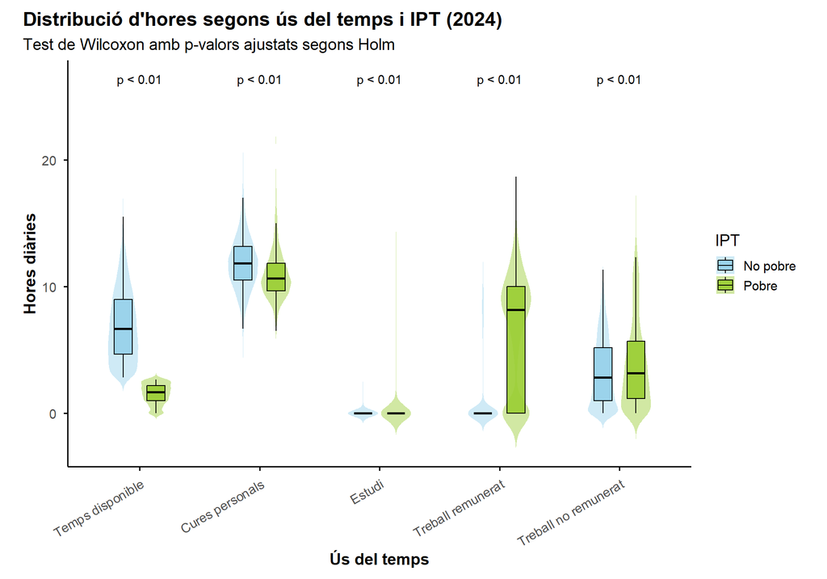

```r
mostra(plot_us_temps(dades_long_2024, "IPT_FACTOR",
                     "Distribució d'hores segons ús del temps i IPT (2024)", "IPT"),
       "us_temps_ipt", 10, 7)
```

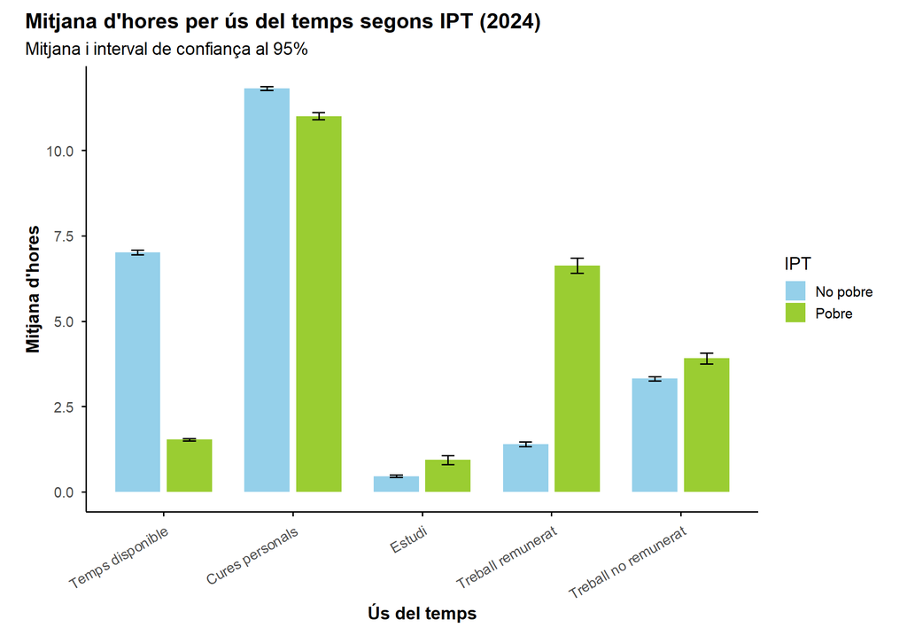

```r
mostra(plot_mitjanes(dades_long_2024, "IPT_FACTOR",
                     "Mitjana d'hores per ús del temps segons IPT (2024)", "IPT"),
       "mitjanes_ipt", 10, 7)
```

El gràfic de violins i caixes mostra la distribució: la línia negra de la caixa és la mediana, els extrems de la caixa el 25% i el 75%, i l’amplada del violí la densitat d’individus.

## 4.2 3.2 Sexe

```r
taula_us_temps(dades_wide_2024, "SEXE", "Distribució del temps segons sexe")
```

Distribució del temps segons sexe

|  | [ALL] | Dona | Home | p.overall |
| --- | --- | --- | --- | --- |
|  | N=8291 | N=4548 | N=3743 |  |
| Temps disponible | 5.90 [5.83;5.97] | 5.61 [5.52;5.71] | 6.25 [6.14;6.36] | <0.001 |
| Cures personals | 11.7 [11.6;11.7] | 11.7 [11.7;11.8] | 11.6 [11.5;11.7] | 0.007 |
| Estudi | 0.55 [0.51;0.60] | 0.53 [0.48;0.59] | 0.58 [0.52;0.65] | 0.234 |
| Treball remunerat | 2.45 [2.37;2.54] | 2.13 [2.02;2.24] | 2.84 [2.71;2.98] | <0.001 |
| Treball no remunerat | 3.44 [3.37;3.50] | 4.01 [3.92;4.09] | 2.74 [2.66;2.82] | <0.001 |

### 4.2.1 3.2.1 IPT segons sexe

```r
knitr::kable(resum_ipt(dades_wide_2024, "SEXE"), caption = "Pobresa temporal segons sexe")
```

Pobresa temporal segons sexe

| Grup | N | Pobres | % pobres | IC 95% |
| --- | --- | --- | --- | --- |
| Dona | 4548 | 952 | 20.9 | [19.8, 22.1] |
| Home | 3743 | 730 | 19.5 | [18.2, 20.8] |

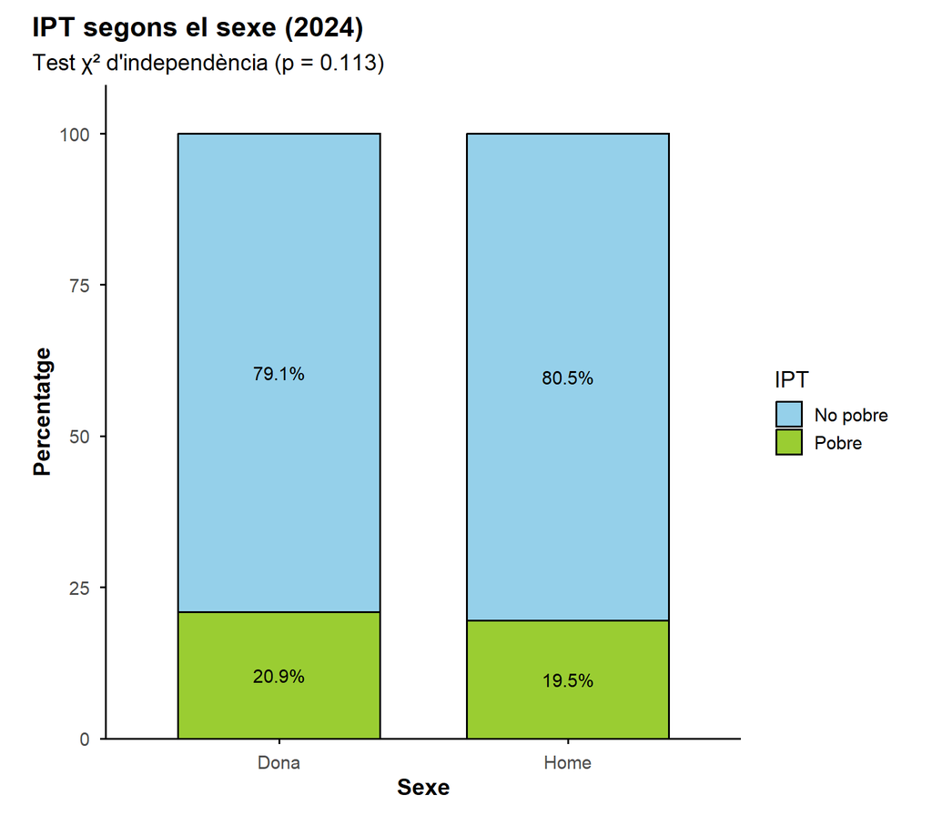

```r
mostra(plot_ipt(dades_wide_2024, "SEXE", "IPT segons el sexe (2024)", "Sexe"), "ipt_sexe")
```

Si el p-valor és superior a 0.05 no es pot rebutjar la hipòtesi nul·la d’independència: no s’observa una associació estadísticament significativa entre sexe i pobresa temporal.

### 4.2.2 3.2.2 Ús del temps segons sexe

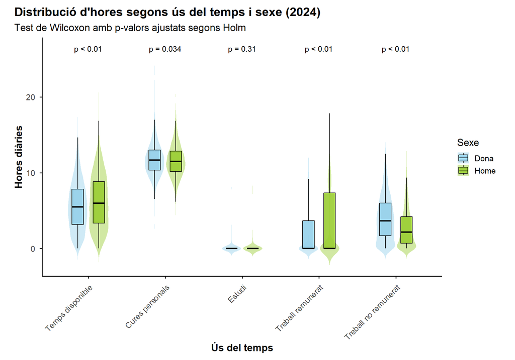

```r
mostra(plot_us_temps(dades_long_2024, "SEXE",
                     "Distribució d'hores segons ús del temps i sexe (2024)", "Sexe", angle = 45),
       "us_temps_sexe", 10, 7)
```

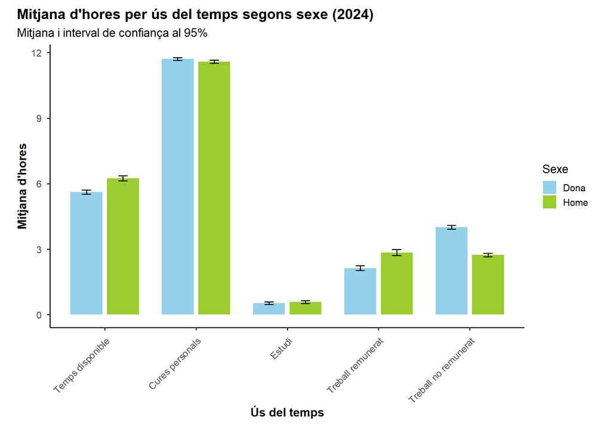

```r
mostra(plot_mitjanes(dades_long_2024, "SEXE",
                     "Mitjana d'hores per ús del temps segons sexe (2024)", "Sexe", angle = 45),
       "mitjanes_sexe", 10, 7)
```

### 4.2.3 3.2.3 Sexe i IPT envers l’ús del temps

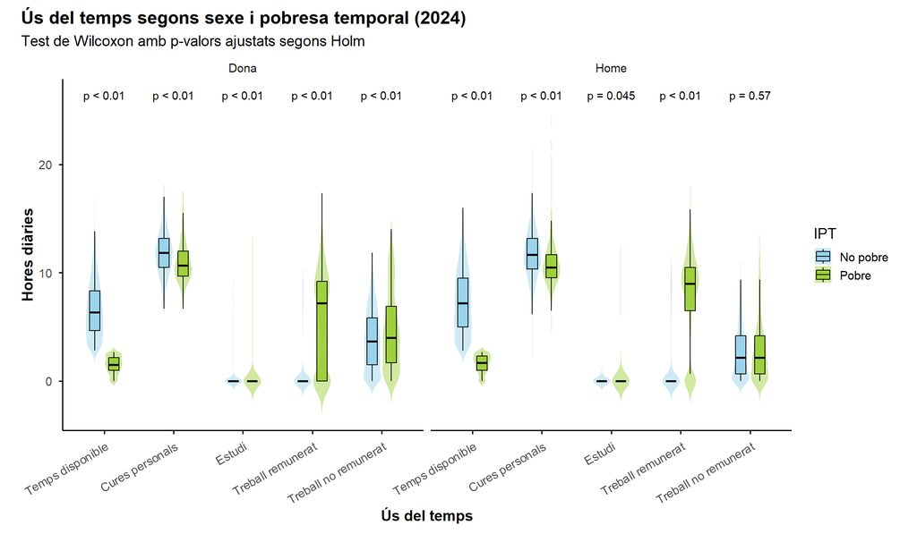

```r
mostra(plot_us_temps(dades_long_2024, "IPT_FACTOR",
                     "Ús del temps segons sexe i pobresa temporal (2024)", "IPT", facet = "SEXE"),
       "us_temps_sexe_ipt", 12, 7)
```

## 4.3 3.3 Àrea urbana

### 4.3.1 3.3.1 IPT segons l’àrea urbana

```r
knitr::kable(resum_ipt(dades_wide_2024, "DEGURBA"), caption = "Pobresa temporal segons àrea urbana")
```

Pobresa temporal segons àrea urbana

| Grup | N | Pobres | % pobres | IC 95% |
| --- | --- | --- | --- | --- |
| Urbà | 4965 | 959 | 19.3 | [18.2, 20.4] |
| Semiurbà | 2354 | 499 | 21.2 | [19.6, 22.9] |
| Rural | 972 | 224 | 23.0 | [20.4, 25.8] |

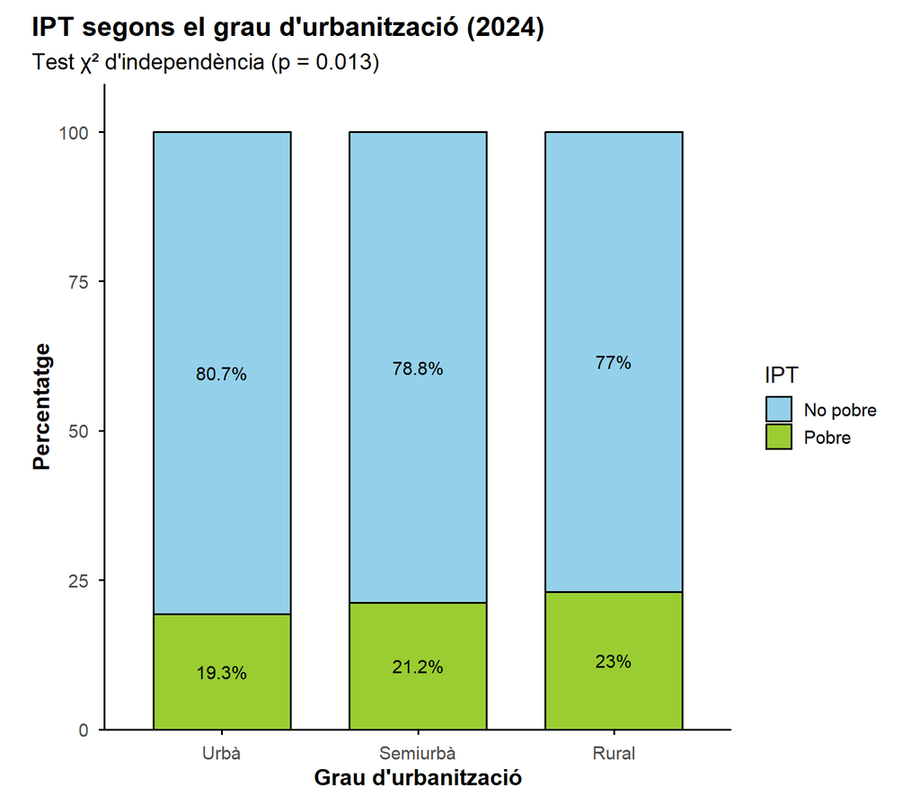

```r
mostra(plot_ipt(dades_wide_2024, "DEGURBA", "IPT segons el grau d'urbanització (2024)",
                "Grau d'urbanització"),
       "ipt_degurba")
```

```r
knitr::kable(pairwise_ipt(dades_wide_2024, "DEGURBA"),
             caption = "Comparacions per parelles (proporcions, ajust de Holm)")
```

Comparacions per parelles (proporcions, ajust de Holm)

| Comparació | p-valor ajustat (Holm) |
| --- | --- |
| Semiurbà vs Urbà | p = 0.128 |
| Rural vs Urbà | p = 0.0265 |
| Rural vs Semiurbà | p = 0.259 |

### 4.3.2 3.3.2 Ús del temps segons l’àrea urbana

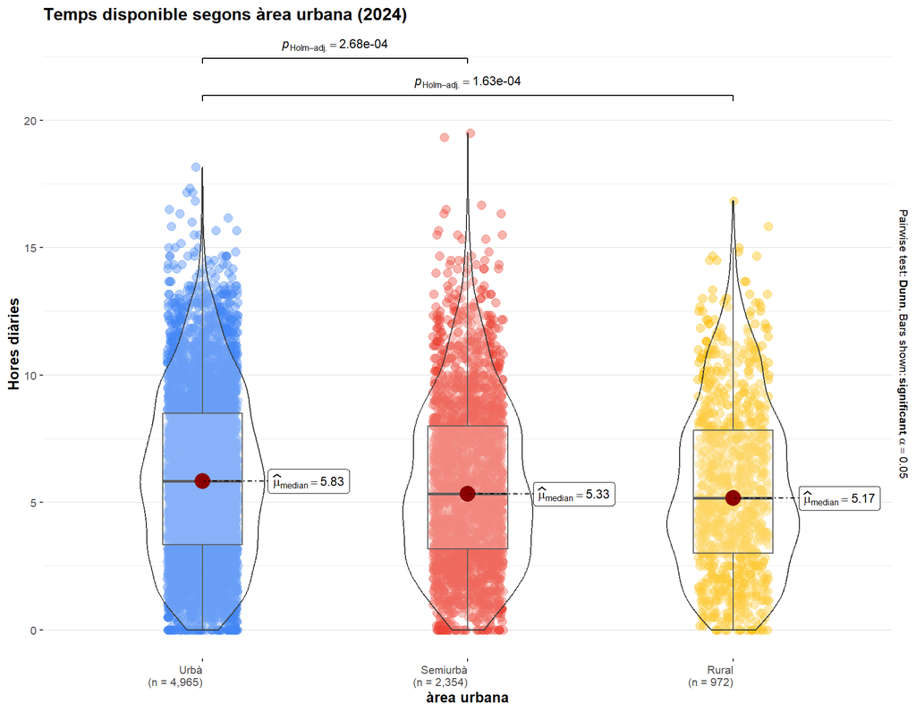

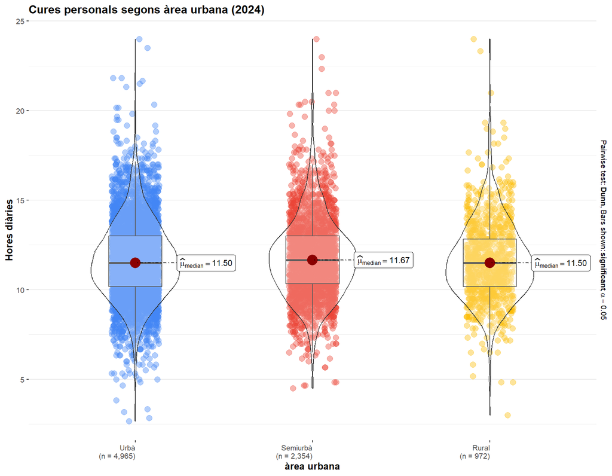

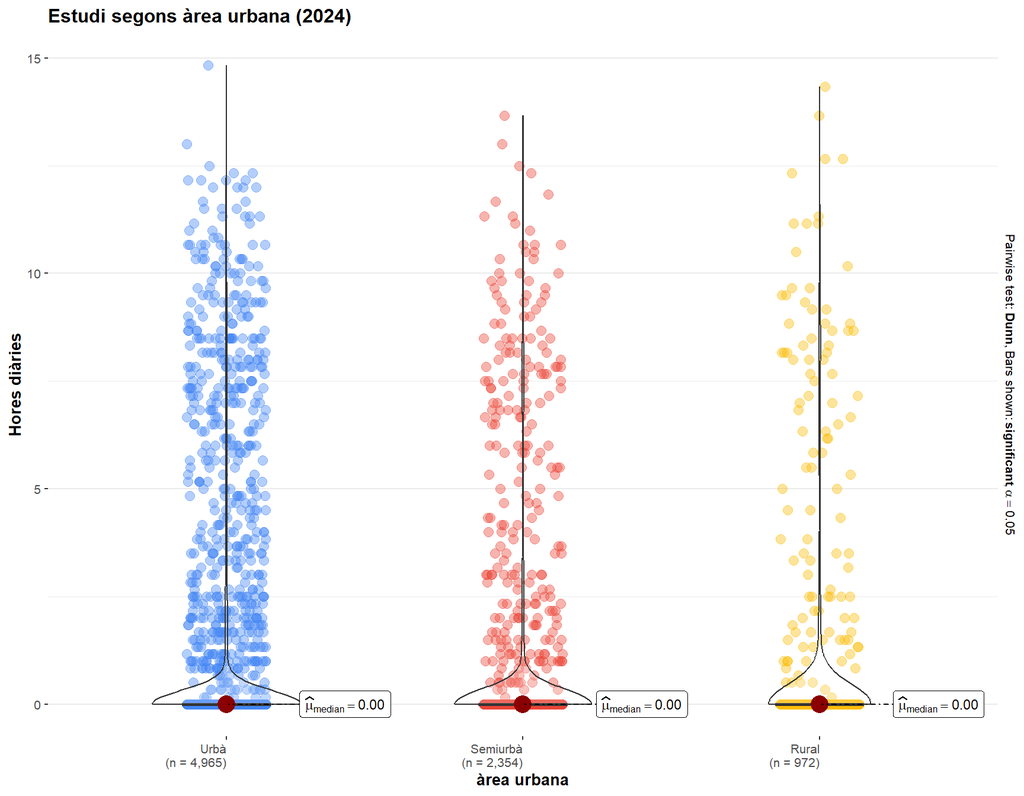

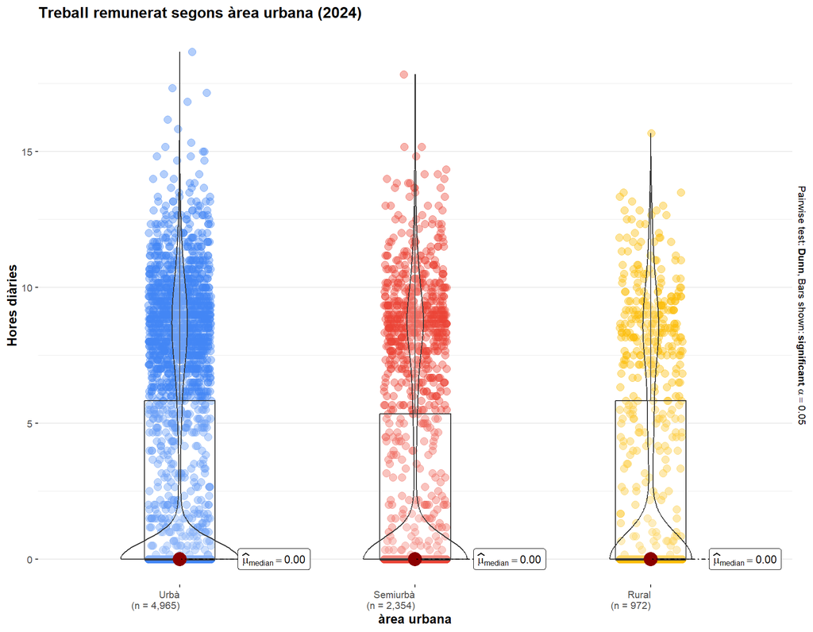

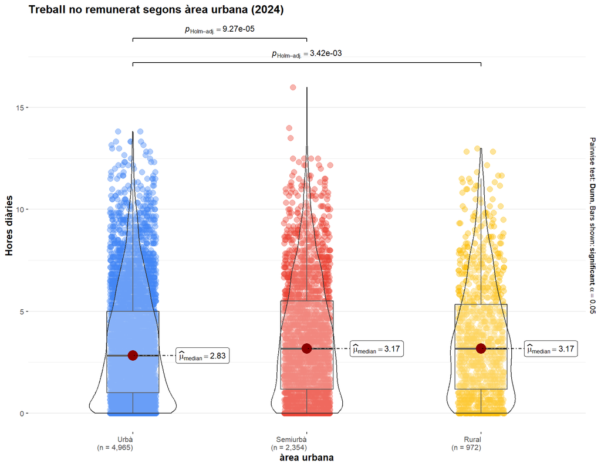

```r
walk(plots_us_temps_grups(dades_long_2024, "DEGURBA", "àrea urbana", angle = 0), print)
```

## 4.4 3.4 Nacionalitat

### 4.4.1 3.4.1 IPT segons la nacionalitat

```r
knitr::kable(resum_ipt(dades_wide_2024, "NAC"), caption = "Pobresa temporal segons nacionalitat")
```

Pobresa temporal segons nacionalitat

| Grup | N | Pobres | % pobres | IC 95% |
| --- | --- | --- | --- | --- |
| Espanyola | 7272 | 1389 | 19.1 | [18.2, 20.0] |
| Estrangera | 1019 | 293 | 28.8 | [26.0, 31.6] |

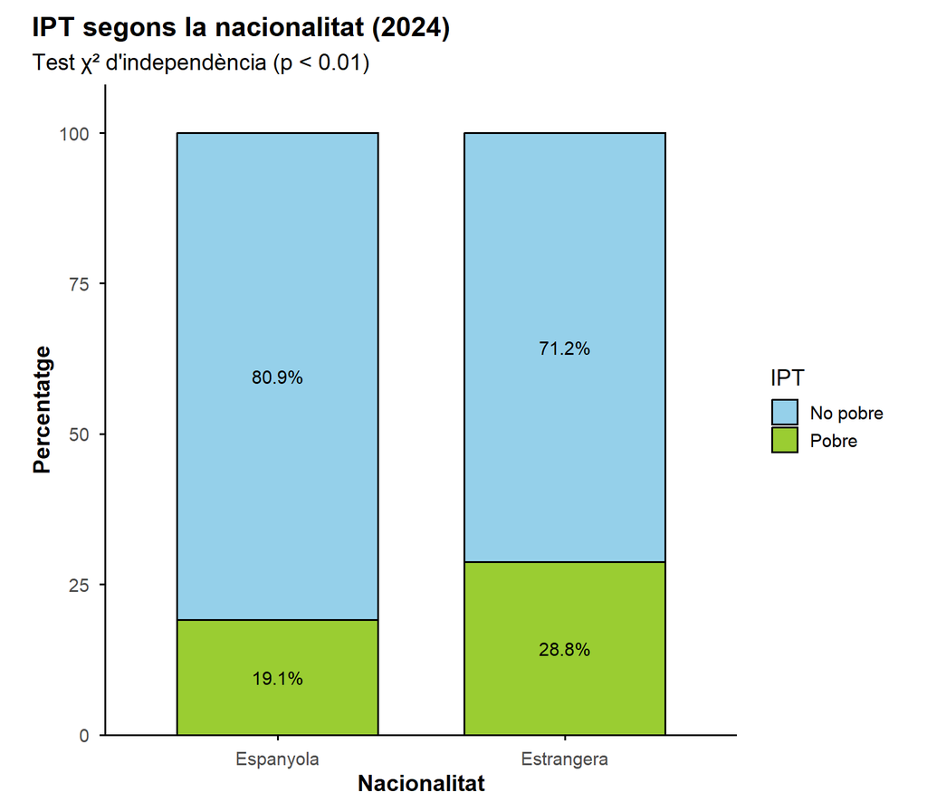

```r
mostra(plot_ipt(dades_wide_2024, "NAC", "IPT segons la nacionalitat (2024)", "Nacionalitat"),
       "ipt_nac")
```

### 4.4.2 3.4.2 Ús del temps segons la nacionalitat

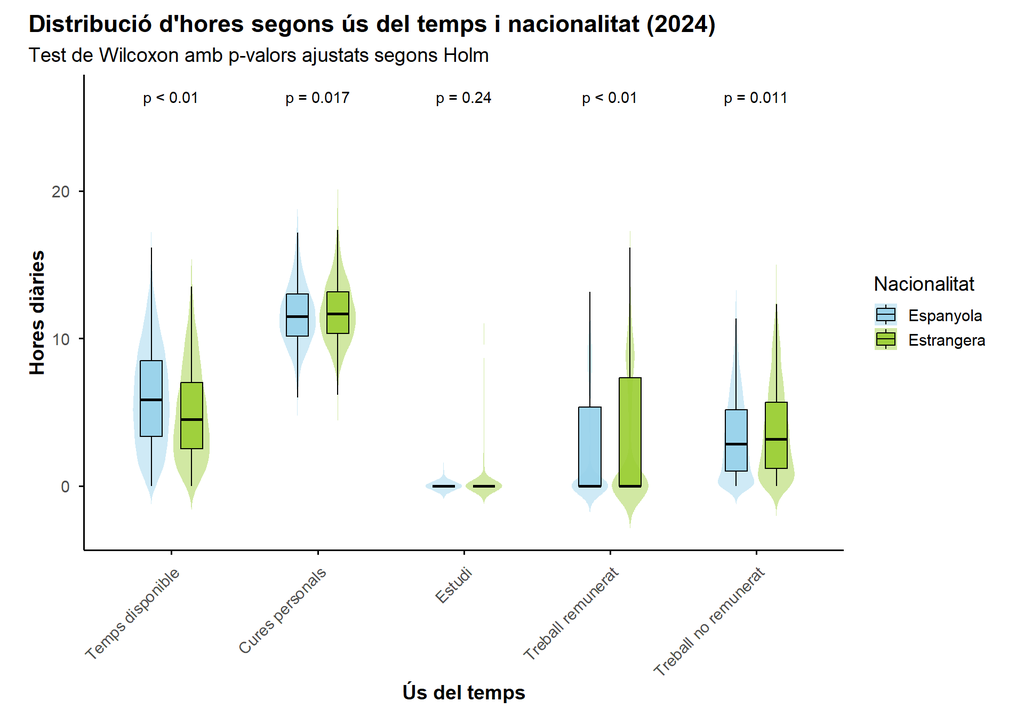

```r
mostra(plot_us_temps(dades_long_2024, "NAC",
                     "Distribució d'hores segons ús del temps i nacionalitat (2024)",
                     "Nacionalitat", angle = 45),
       "us_temps_nac", 10, 7)
```

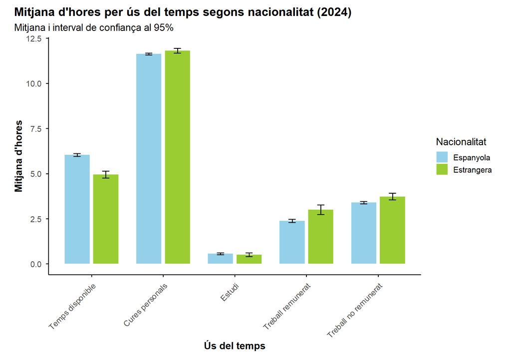

```r
mostra(plot_mitjanes(dades_long_2024, "NAC",
                     "Mitjana d'hores per ús del temps segons nacionalitat (2024)",
                     "Nacionalitat", angle = 45),
       "mitjanes_nac", 10, 7)
```

## 4.5 3.5 Tipus de llar

### 4.5.1 3.5.1 IPT segons el tipus de llar

```r
knitr::kable(resum_ipt(dades_wide_2024, "TIPUS_LLAR"), caption = "Pobresa temporal segons tipus de llar")
```

Pobresa temporal segons tipus de llar

| Grup | N | Pobres | % pobres | IC 95% |
| --- | --- | --- | --- | --- |
| Parella amb fills <25 | 2814 | 825 | 29.3 | [27.6, 31.0] |
| Unipersonal | 1382 | 157 | 11.4 | [9.7, 13.2] |
| Parella sense fills | 1893 | 239 | 12.6 | [11.2, 14.2] |
| Monoparental fills <25 | 532 | 148 | 27.8 | [24.0, 31.8] |
| Monoparental fills ≥25 | 365 | 54 | 14.8 | [11.3, 18.9] |
| Parella amb fills ≥25 | 526 | 91 | 17.3 | [14.2, 20.8] |
| Altres | 779 | 168 | 21.6 | [18.7, 24.6] |

[figure not shown]

```r
mostra(plot_ipt(dades_wide_2024, "TIPUS_LLAR", "IPT segons el tipus de llar (2024)",
                "Tipus de llar", angle = 45),
       "ipt_tipus_llar", 9, 7)
```

```r
datatable(pairwise_ipt(dades_wide_2024, "TIPUS_LLAR"), rownames = FALSE,
          caption = "Comparacions per parelles (proporcions, ajust de Holm)",
          options = list(pageLength = 10))
```

| Comparació | p-valor ajustat (Holm) |
| --- | --- |
| Unipersonal vs Parella amb fills &lt;25 | p &lt; 0.01 |
| Parella sense fills vs Parella amb fills &lt;25 | p &lt; 0.01 |
| Parella sense fills vs Unipersonal | p = 1 |
| Monoparental fills &lt;25 vs Parella amb fills &lt;25 | p = 1 |
| Monoparental fills &lt;25 vs Unipersonal | p &lt; 0.01 |
| Monoparental fills &lt;25 vs Parella sense fills | p &lt; 0.01 |
| Monoparental fills ≥25 vs Parella amb fills &lt;25 | p &lt; 0.01 |
| Monoparental fills ≥25 vs Unipersonal | p = 0.445 |
| Monoparental fills ≥25 vs Parella sense fills | p = 1 |
| Monoparental fills ≥25 vs Monoparental fills &lt;25 | p &lt; 0.01 |

[output cut: 11 more lines]

### 4.5.2 3.5.2 Ús del temps segons el tipus de llar

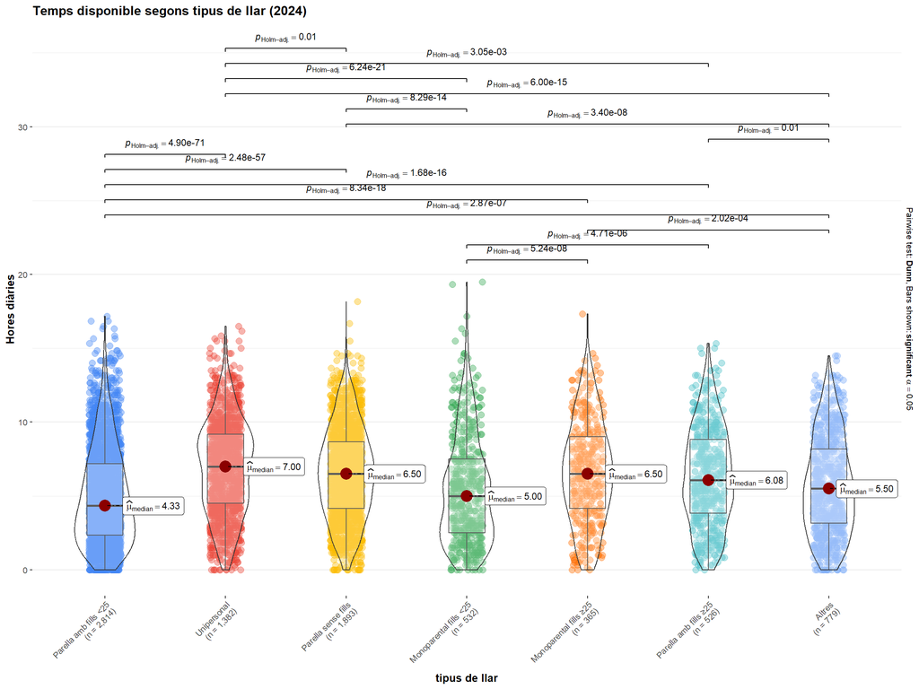

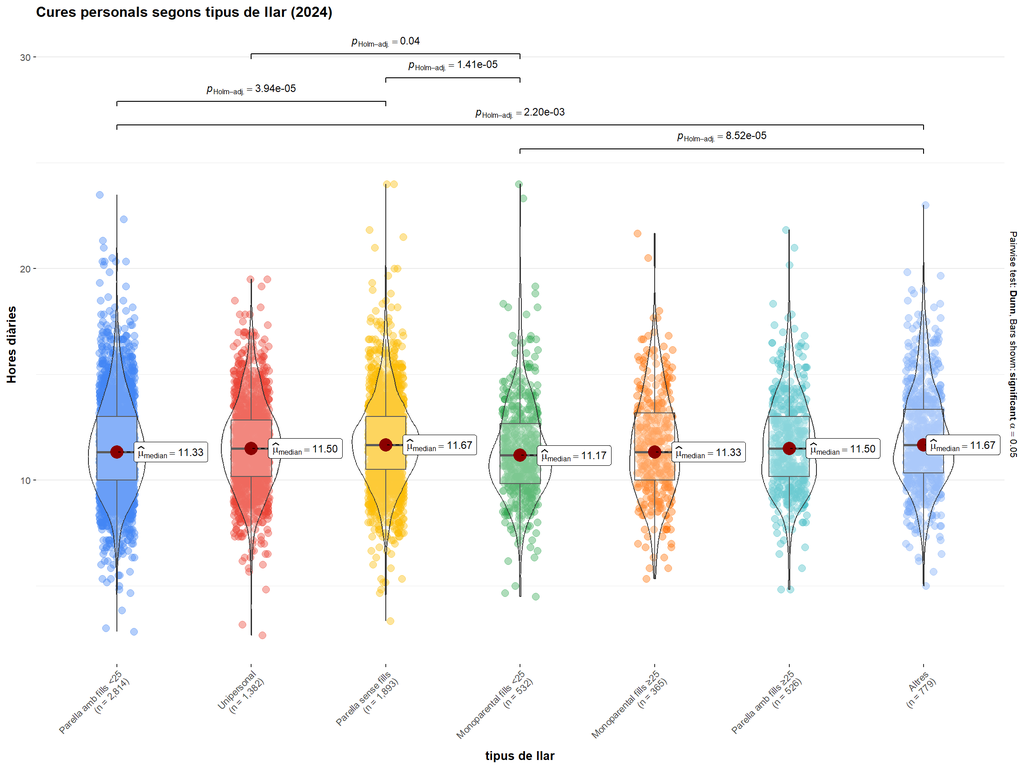

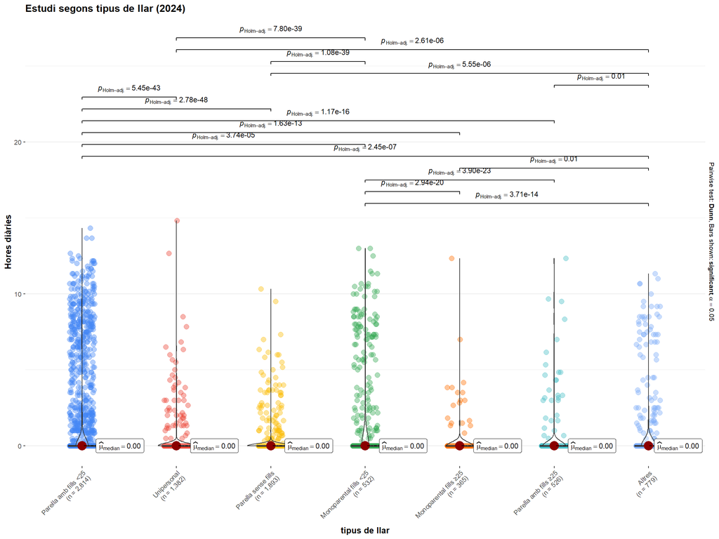

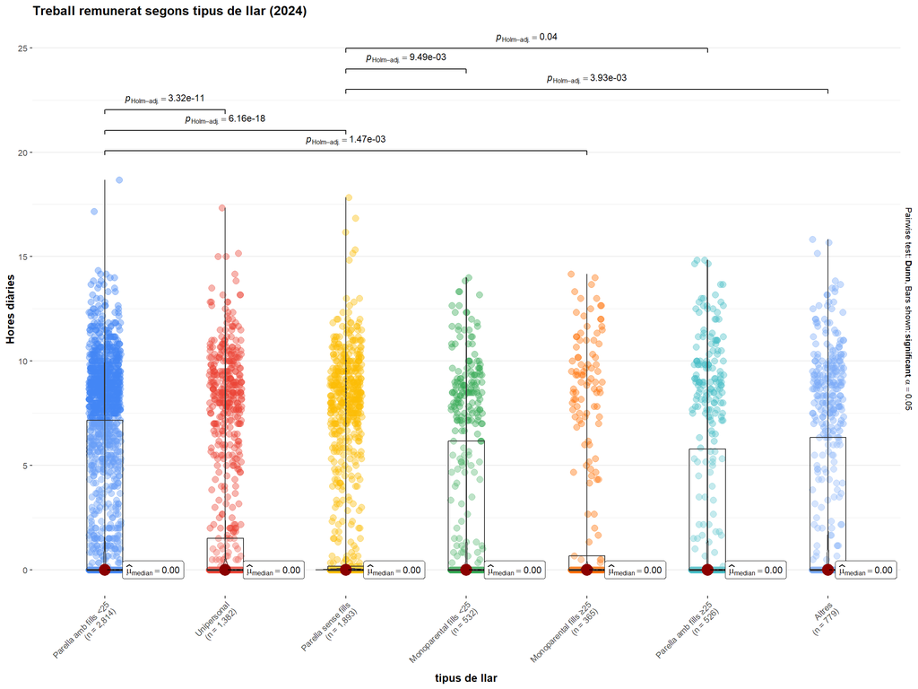

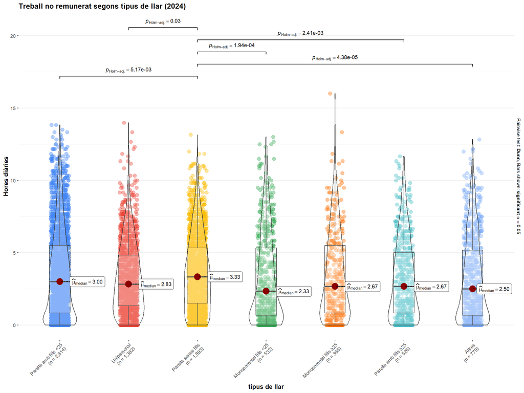

```r
walk(plots_us_temps_grups(dades_long_2024, "TIPUS_LLAR", "tipus de llar"), print)
```

## 4.6 3.6 Tram d’ingressos

### 4.6.1 3.6.1 IPT segons el tram d’ingressos

```r
knitr::kable(resum_ipt(dades_wide_2024, "TRAM_INGRESSOS"), caption = "Pobresa temporal segons tram d'ingressos")
```

Pobresa temporal segons tram d’ingressos

| Grup | N | Pobres | % pobres | IC 95% |
| --- | --- | --- | --- | --- |
| 900 € o menys | 511 | 66 | 12.9 | [10.1, 16.1] |
| De 901 € a 1.500 € | 1556 | 270 | 17.4 | [15.5, 19.3] |
| De 1.501 € a 1.900 € | 970 | 182 | 18.8 | [16.4, 21.4] |
| De 1.901 € a 2.500 € | 1423 | 321 | 22.6 | [20.4, 24.8] |
| Més de 2.500 € | 2660 | 644 | 24.2 | [22.6, 25.9] |

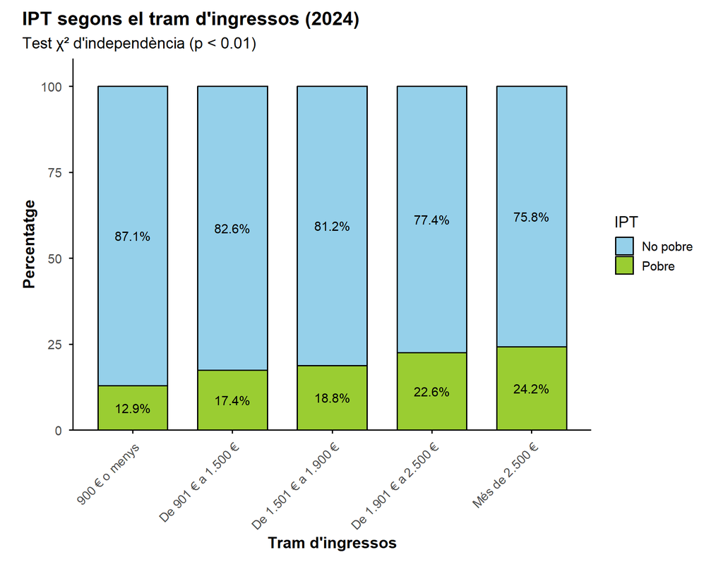

```r
mostra(plot_ipt(dades_wide_2024, "TRAM_INGRESSOS", "IPT segons el tram d'ingressos (2024)",
                "Tram d'ingressos", angle = 45),
       "ipt_tram_ingressos", 9, 7)
```

```r
datatable(pairwise_ipt(dades_wide_2024, "TRAM_INGRESSOS"), rownames = FALSE,
          caption = "Comparacions per parelles (proporcions, ajust de Holm)",
          options = list(pageLength = 10))
```

| Comparació | p-valor ajustat (Holm) |
| --- | --- |
| De 901 € a 1.500 € vs 900 € o menys | p = 0.0883 |
| De 1.501 € a 1.900 € vs 900 € o menys | p = 0.0262 |
| De 1.501 € a 1.900 € vs De 901 € a 1.500 € | p = 0.504 |
| De 1.901 € a 2.500 € vs 900 € o menys | p &lt; 0.01 |
| De 1.901 € a 2.500 € vs De 901 € a 1.500 € | p &lt; 0.01 |
| De 1.901 € a 2.500 € vs De 1.501 € a 1.900 € | p = 0.0883 |
| Més de 2.500 € vs 900 € o menys | p &lt; 0.01 |
| Més de 2.500 € vs De 901 € a 1.500 € | p &lt; 0.01 |
| Més de 2.500 € vs De 1.501 € a 1.900 € | p &lt; 0.01 |
| Més de 2.500 € vs De 1.901 € a 2.500 € | p = 0.504 |

### 4.6.2 3.6.2 Ús del temps segons el tram d’ingressos

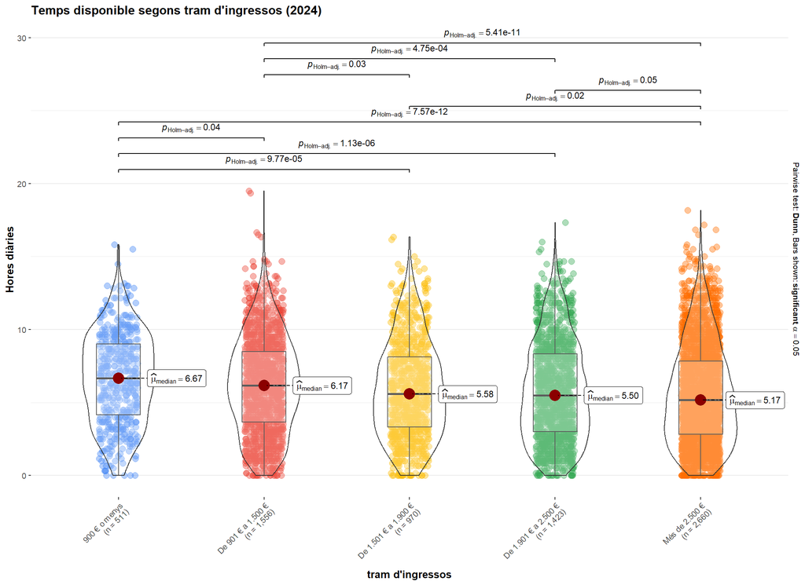

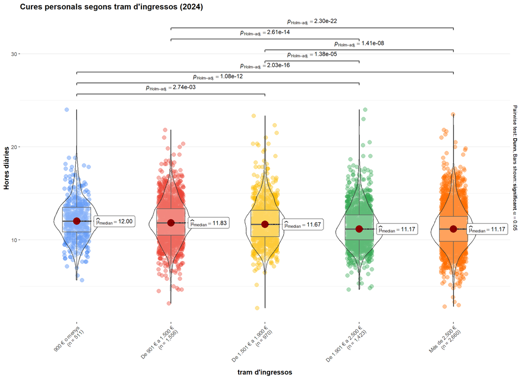

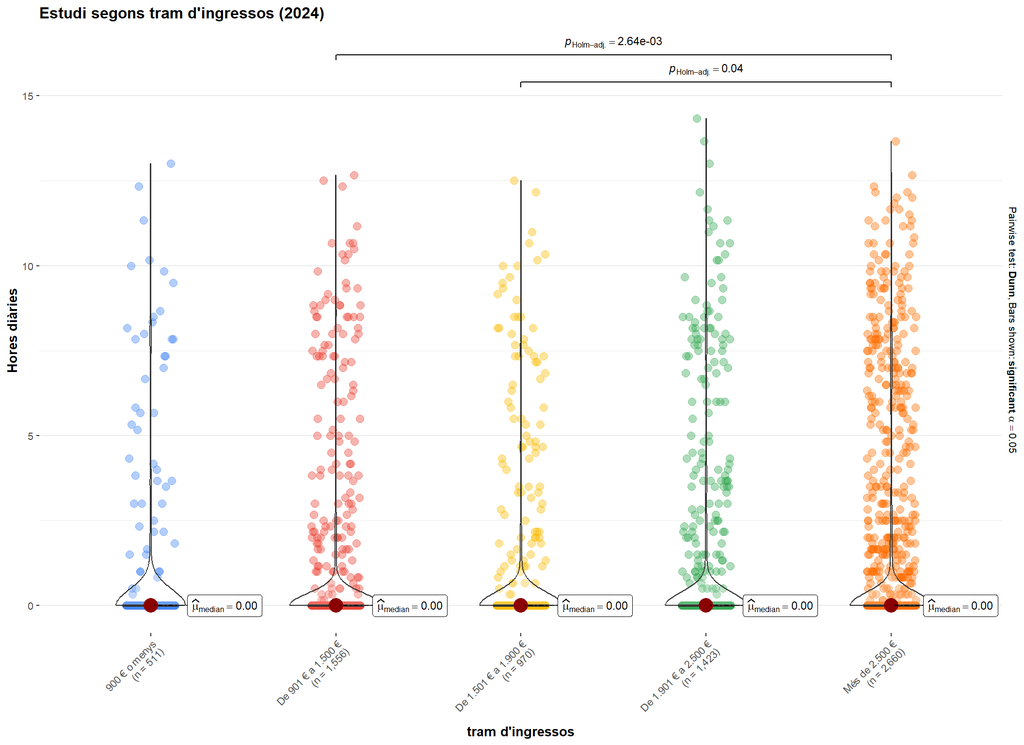

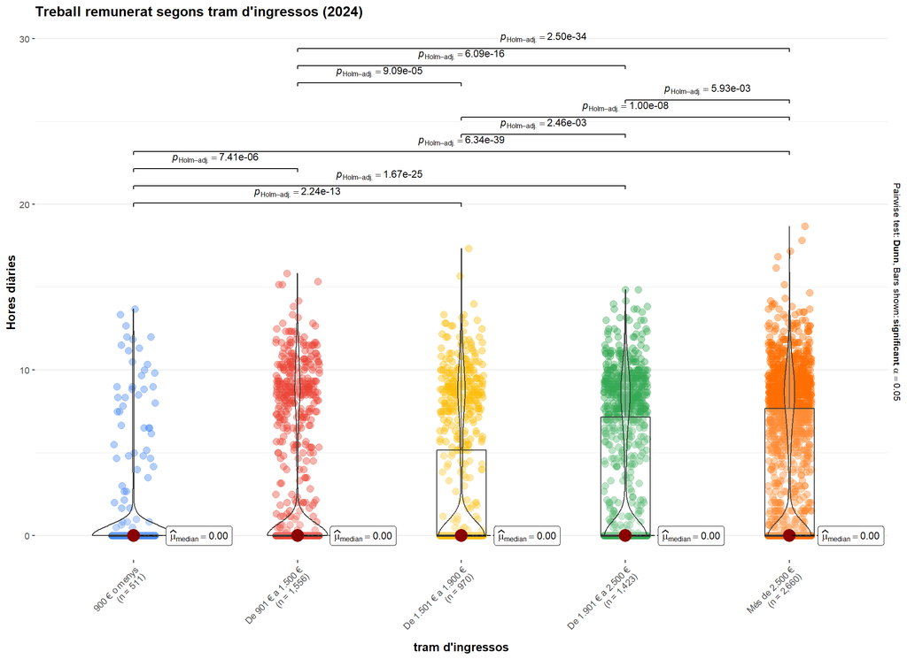

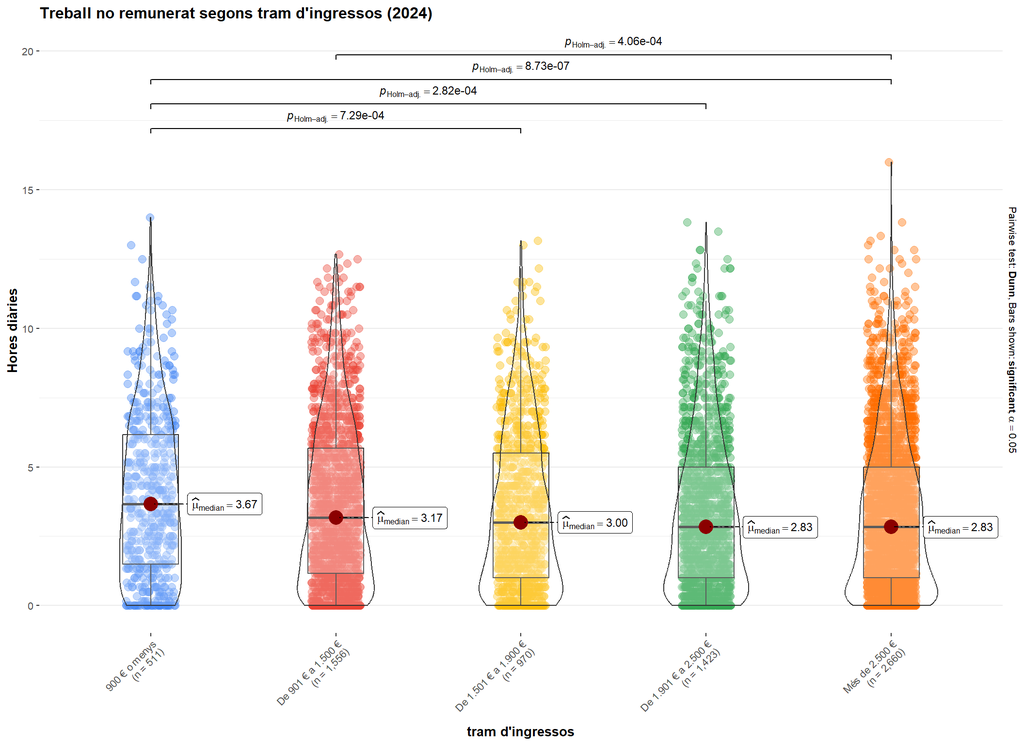

```r
walk(plots_us_temps_grups(dades_long_2024, "TRAM_INGRESSOS", "tram d'ingressos"), print)
```

## 4.7 3.7 Càrrega mental

```r
colors_carrega <- setNames(
  c("#95D0EA", "#9ACD32", "#E84FA3", "#E88B3A", "#9B95D6", "#E7B91A"),
  levels(dades_mentals_2024$resposta)
)
```

### 4.7.1 3.7.1 Segons sexe

```r
knitr::kable(resum_chi_carrega(dades_mentals_2024, "SEXE"),
             caption = "Test χ² d'independència i V de Cramér: tasca × sexe")
```

Test χ² d’independència i V de Cramér: tasca × sexe

| Tasca | N | χ² | gl | p-valor | V de Cramér |
| --- | --- | --- | --- | --- | --- |
| Àpats | 7631 | 1380.22 | 5 | p < 0.01 | 0.425 |
| Compres | 7631 | 883.85 | 5 | p < 0.01 | 0.340 |
| Neteja | 7631 | 1922.34 | 5 | p < 0.01 | 0.502 |
| Roba infants | 1311 | 624.59 | 4 | p < 0.01 | 0.690 |
| Gestions mèdiques | 1311 | 439.87 | 5 | p < 0.01 | 0.579 |
| Relacions escolars/socials | 1311 | 345.67 | 4 | p < 0.01 | 0.513 |

```r
datatable(taula_carrega(dades_mentals_2024, "SEXE"), rownames = FALSE,
          caption = "Percentatge de respostes per sexe i tasca",
          options = list(pageLength = 12))
```

| Grup | Tasca | Majoritàriament l'enquestat/ada | A parts iguals entre l'enquestat/ada i la parella | Majoritàriament la parella de l'enquestat/ada | Un altre membre de la llar | Una persona de fora de la llar | Altres situacions |
| --- | --- | --- | --- | --- | --- | --- | --- |
| Dona | Àpats | 64.3 | 17.3 | 4.9 | 9.9 | 2.2 | 1.4 |
| Dona | Compres | 58.8 | 21.1 | 5.9 | 10.3 | 2.5 | 1.3 |
| Dona | Neteja | 66.1 | 16.6 | 2.5 | 8.9 | 4.5 | 1.4 |
| Dona | Roba infants | 67.8 | 18.9 | 3.6 | 7.9 | 0 | 1.7 |
| Dona | Gestions mèdiques | 59.6 | 26.3 | 4.9 | 7.5 | 0 | 1.7 |
| Dona | Relacions escolars/socials | 54.7 | 27.9 | 5.6 | 7 | 0 | 4.9 |
| Home | Àpats | 27.5 | 22.8 | 31 | 14.6 | 2.1 | 1.9 |
| Home | Compres | 29.4 | 28 | 24.3 | 15 | 1.8 | 1.6 |
| Home | Neteja | 23.4 | 22.8 | 33.3 | 14.7 | 4 | 1.7 |
| Home | Roba infants | 6.9 | 26.1 | 54.3 | 11.1 | 0 | 1.5 |

[output cut: 2 more lines]

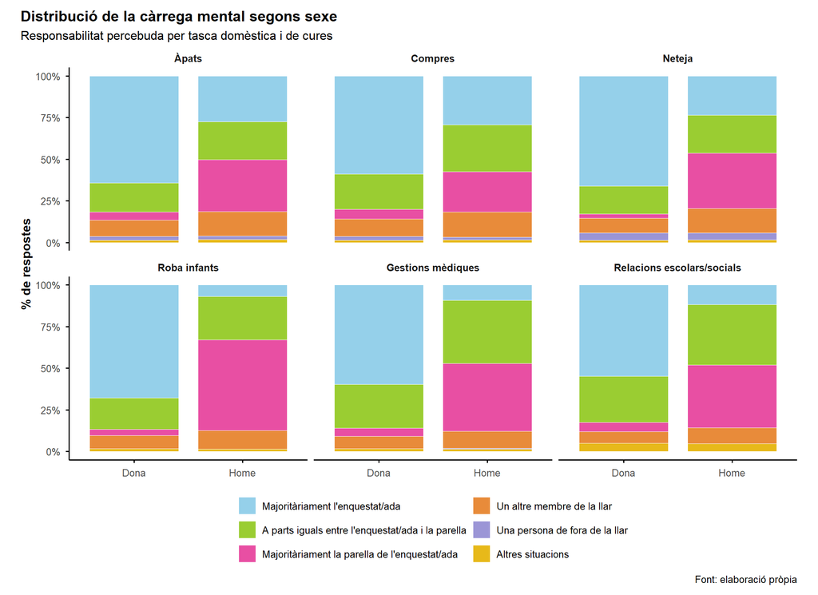

```r
mostra(plot_carrega(dades_mentals_2024, "SEXE", "Distribució de la càrrega mental segons sexe"),
       "carrega_sexe", 11, 8)
```